# Introduction

With the rise and availability of technology, younger generations have access to digital media. There have been many studies showing that social media can have a negative impact on mental health through cyberbullyig, comparing oneself to others online, and the addictive nature of social media. Now in a time where technology is needed to live, it is difficult to limit and protect users from these risks.

This project explores the dataset "Gen-Z Social Media Usage Dataset" available publicly on Kaggle. It contains 1,000,000 records each representing a unique Gen-Z social media user. The dataset includes behavioral, demographic, and psychological information on each user. The purpose of this project is to obtain insight on social media usage patterns and mental health trends among Gen-Z (ages 13-27).

Through this we could be able to identify who are most at risk, and causes of poor mental health early in youth.

Note: This is a synthetic dataset, but was designed to realistically resemble the modern digital world.

```python
%pip install pandas matplotlib seaborn numpy statsmodels
```

[output not shown]

```python
import pandas as pd
import matplotlib.pyplot as plt
import seaborn as sns
import statsmodels.api as sm

%matplotlib inline
sns.set_theme(style='whitegrid')
```

```python
# load in dataset
df = pd.read_csv('genz_social_media_usage_1M.csv')
df.head()
```

|  | age | gender | country | daily_usage_hours | primary_platform | num_platforms_used | purpose | avg_session_minutes | night_usage | mental_health_score | addiction_level | screen_time_before_sleep |
| --- | --- | --- | --- | --- | --- | --- | --- | --- | --- | --- | --- | --- |
| 0 | 19 | Male | Australia | 2.658617 | Snapchat | 4 | Education | 29.222443 | 0 | 6.705830 | Medium | 15.779443 |
| 1 | 16 | Female | USA | 5.685387 | Twitter | 3 | Socializing | 32.464726 | 1 | 6.633111 | High | 47.714864 |
| 2 | 25 | Female | India | 2.782420 | TikTok | 2 | Socializing | 18.170204 | 1 | 6.035397 | Medium | 62.524625 |
| 3 | 27 | Male | India | 3.486598 | YouTube | 4 | Education | 22.493804 | 1 | 8.110861 | Medium | 31.935102 |
| 4 | 23 | Female | India | 3.748829 | TikTok | 1 | Entertainment | 27.358410 | 1 | 6.658598 | Medium | 29.466046 |

# Questions to be Answered

1. Which gender uses social media more?
2. What is the main purpose people use social media?
3. What is the average session time in India?
4. How does daily social media usage affect user mental health?
5. Is the average session minutes affected by the user's age?
6. Can we predict a user's mental health score based on social media habits?

# Question 1: Which gender uses social media more?

We will see if there are any groups more prone to using social media for longer periods of time using the mean and median daily usage time for each gender. Then side-by-side box plots will be compare the variability for the data of each gender.

```python
# groups users by gender and finds the mean, median, and count of
gender_table = df.groupby('gender')['daily_usage_hours'].agg(['mean', 'median', 'count'])
gender_table
```

| gender | mean | median | count |
| --- | --- | --- | --- |
| Female | 3.515156 | 3.502646 | 460801 |
| Male | 3.514208 | 3.503110 | 460049 |
| Other | 3.521148 | 3.508299 | 38632 |

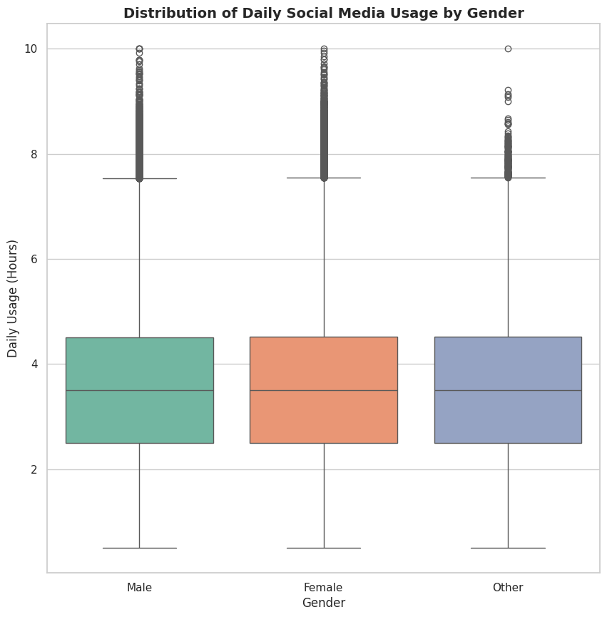

```python
# creates side-by-side boxplots for a 5-number summary on each gender
plt.figure(figsize=(10,10))
sns.boxplot(data=df, x='gender', y='daily_usage_hours', palette='Set2', showfliers=True)

plt.title('Distribution of Daily Social Media Usage by Gender', fontsize=14, fontweight='bold')
plt.xlabel('Gender', fontsize=12)
plt.ylabel('Daily Usage (Hours)', fontsize=12)

plt.show()
```

# Question 2: What is the main purpose people use social media?

The purpose of this question is to determine what keeps users online. A bar graph will be used to show how many users fall under each purpose category.

```python
# counts how many times each unique value appears in purpose column
purpose_counts = df['purpose'].value_counts()

#calculates percentage of each purpose counts by the total number of users
purpose_percentages = df['purpose'].value_counts(normalize=True)

purpose_summary = pd.DataFrame({
    'Total Users': purpose_counts,
    'Percentage (%)': purpose_percentages.round(2)
})

purpose_summary
```

| purpose | Total Users | Percentage (%) |
| --- | --- | --- |
| Entertainment | 383924 | 0.40 |
| Socializing | 240004 | 0.25 |
| Education | 192235 | 0.20 |
| News | 95682 | 0.10 |
| Content Creation | 47637 | 0.05 |

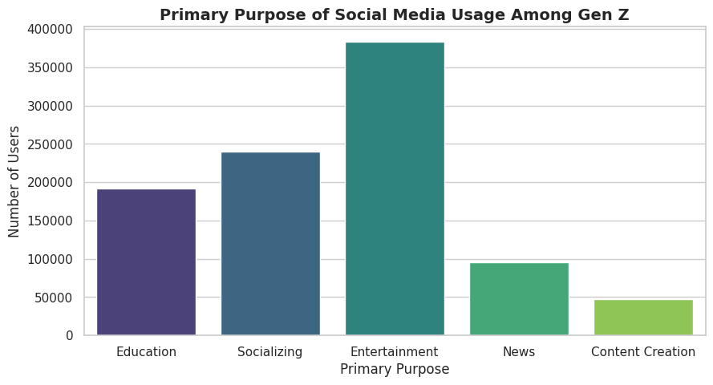

```python
plt.figure(figsize=(10,5))

# creates the bar graph with each bar as one purpose
sns.countplot(data=df, x='purpose', palette='viridis')

plt.title('Primary Purpose of Social Media Usage Among Gen Z', fontsize=14, fontweight='bold')
plt.xlabel('Primary Purpose', fontsize = 12)
plt.ylabel('Number of Users', fontsize=12)

plt.show()
```

From the table and the bar chart, we can clearly see that Entertainment is the biggest reason people use social media. The table tells us that about 40 percent of users from the dataset use social media for entertainment. We can easily see how many people chose each category and compare them to each other. Like how Socializing is the 2nd biggest reason people use social media, and Content Creation is the smallest.

# Question 3: What is the average session time in India?

```python
# only selects the rows of users in India
india_users = df[df['country'] == 'India']

# takes the average of the average session time of all Indian social media users
india_avg_session = india_users['avg_session_minutes'].mean()

india_table = pd.DataFrame({
    'Country':'India',
    'Average Session Duration (min)': [india_avg_session]
})

india_table
```

|  | Country | Average Session Duration (min) |
| --- | --- | --- |
| 0 | India | 25.087886 |

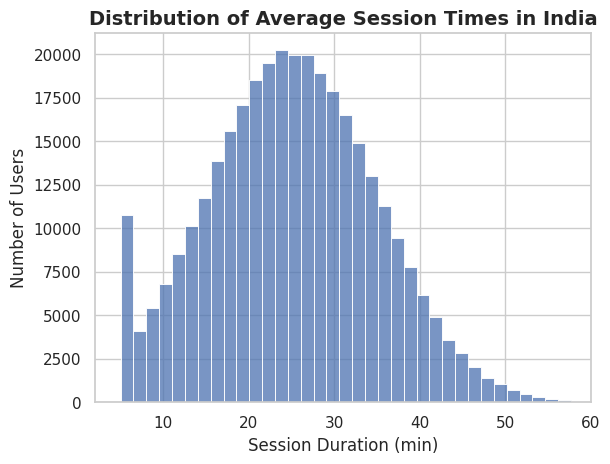

```python
# creates a histogram of average session times of Indian users
sns.histplot(data=india_users, x='avg_session_minutes', bins=50)

plt.title('Distribution of Average Session Times in India', fontsize=14, fontweight='bold')
plt.xlabel('Session Duration (min)', fontsize=12)
plt.ylabel('Number of Users', fontsize=12)
plt.xlim(2, 60)

plt.show()
```

# Question 4: How does daily social media usage affect user mental health?

This is important for the problem as a whole. If there is a correlation to how much time users spend on social media and a direct impact on mental health, we can find one of the factors that makes social media a problem to younger generations.

```python
# takes a random sample of 10,000 from the dataset
sample = df.sample(n=10000, random_state = 12345)

# puts the data in descending order on daily_usage_hours
sample[['daily_usage_hours','mental_health_score']].sort_values(by='daily_usage_hours', ascending=False)
```

|  | daily_usage_hours | mental_health_score |
| --- | --- | --- |
| 728681 | 9.619107 | 1.528330 |
| 248393 | 8.855135 | 3.405288 |
| 518750 | 8.769027 | 1.551111 |
| 311766 | 8.677846 | 2.740564 |
| 336608 | 8.464144 | 2.400924 |
| ... | ... | ... |
| 949398 | 0.500000 | 9.436254 |
| 135053 | 0.500000 | 9.959594 |
| 151390 | 0.500000 | 10.000000 |
| 920892 | 0.500000 | 9.238710 |
| 590183 | 0.500000 | 10.000000 |

10000 rows × 2 columns

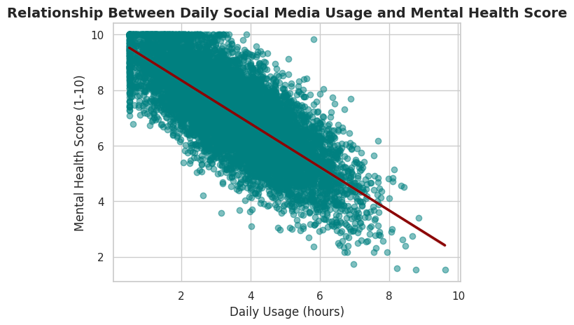

```python
# creates a scatterplot and a trendline using daily usage and mental health
sns.regplot(data=sample, x='daily_usage_hours', y='mental_health_score', scatter_kws={'alpha':0.5, 'color':'teal'}, line_kws={'color':'darkred', 'linewidth':2.5})

plt.title('Relationship Between Daily Social Media Usage and Mental Health Score', fontsize=14, fontweight='bold')
plt.xlabel('Daily Usage (hours)', fontsize=12)
plt.ylabel('Mental Health Score (1-10)', fontsize=12)
```

The scatterplot and table uses information on a random sample of 10,000 users. This was so it would better fit in the plot. The scatterplot shows us that there is a strong, negative correlation between social media usage and mental health. As we can see, the users who spend more time on social media have lower mental health scores, meaning worse mental health. I also included the table of real values from the sample so we can compare mental health scores of those with most usage to those with least usage.

# Question 5: Is the average session minutes affected by the user's age?

The purpose of this question is to see whether age plays a factor into social media usage. This could help determine if certain age groups, particularly young teens, are more prone to social media addiction and therefore worse mental health.

```python
# takes the average of average session minutes for each age group
age_avg = df.groupby('age')['avg_session_minutes'].mean().reset_index()

age_avg
```

|  | age | avg_session_minutes |
| --- | --- | --- |
| 0 | 13 | 25.078427 |
| 1 | 14 | 25.120735 |
| 2 | 15 | 25.105048 |
| 3 | 16 | 25.102194 |
| 4 | 17 | 25.051021 |
| 5 | 18 | 25.128878 |
| 6 | 19 | 25.051168 |
| 7 | 20 | 25.106250 |
| 8 | 21 | 25.153149 |
| 9 | 22 | 25.137722 |
| 10 | 23 | 25.076313 |
| 11 | 24 | 25.039179 |
| 12 | 25 | 25.047302 |
| 13 | 26 | 25.065977 |
| 14 | 27 | 25.072452 |

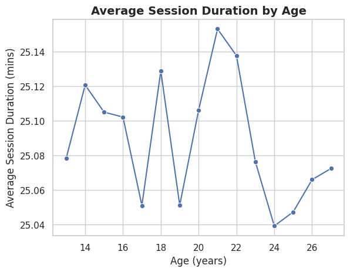

```python
# creates a line chart mapping the averages in the table
sns.lineplot(data=age_avg, x='age', y='avg_session_minutes', marker='o')

plt.title('Average Session Duration by Age', fontsize=14, fontweight='bold')
plt.xlabel('Age (years)', fontsize=12)
plt.ylabel('Average Session Duration (mins)', fontsize=12)

plt.show()
```

# Question 6: Can we predict a user's mental health score based on social media habits?

I will use the variables screen_time_before_sleep, daily_usage_hours, avg_session_minutes, and num_platforms_used to determine this. Each variable will have its own linear regression model, then they will all be put together in another multiple linear regression model to determine which variables play the greatest role in affecting mental health, and possibly predict an individual's mental health score based on them.

```python
cleaned_data = df[['mental_health_score','screen_time_before_sleep', 'daily_usage_hours', 'avg_session_minutes', 'num_platforms_used']].copy()
cleaned_data['screen_time_before_sleep'] = pd.to_numeric(cleaned_data['screen_time_before_sleep'], errors='coerce')
cleaned_data.dropna(inplace=True)
```

Simple Linear Regression for Screentime Before Sleep

```python
X = cleaned_data[['screen_time_before_sleep']]
y = cleaned_data['mental_health_score']
X = sm.add_constant(X)
model = sm.OLS(y, X).fit()
print(model.summary())
```

```
                             OLS Regression Results
===============================================================================
Dep. Variable:     mental_health_score   R-squared:                       0.000
Model:                             OLS   Adj. R-squared:                 -0.000
Method:                  Least Squares   F-statistic:                   0.01537
Date:                 Tue, 05 May 2026   Prob (F-statistic):              0.901
Time:                         22:17:29   Log-Likelihood:            -1.7527e+06
No. Observations:               959481   AIC:                         3.505e+06
Df Residuals:                   959479   BIC:                         3.505e+06
Df Model:                            1
Covariance Type:             nonrobust
============================================================================================
                               coef    std err          t      P>|t|      [0.025      0.975]
--------------------------------------------------------------------------------------------
const                        7.1712      0.004   2048.381      0.000       7.164       7.178
screen_time_before_sleep -9.722e-06   7.84e-05     -0.124      0.901      -0.000       0.000
==============================================================================
Omnibus:                    10698.244   Durbin-Watson:                   2.003
Prob(Omnibus):                  0.000   Jarque-Bera (JB):             9428.088
Skew:                          -0.192   Prob(JB):                         0.00
Kurtosis:                       2.704   Cond. No.                         102.
==============================================================================

Notes:
[1] Standard Errors assume that the covariance matrix of the errors is correctly specified.
```

Simple Linear Regression for Daily Social Media Usage

```python
X = cleaned_data[['daily_usage_hours']]
y = cleaned_data['mental_health_score']
X = sm.add_constant(X)
model = sm.OLS(y, X).fit()
print(model.summary())
```

```
                             OLS Regression Results
===============================================================================
Dep. Variable:     mental_health_score   R-squared:                       0.580
Model:                             OLS   Adj. R-squared:                  0.580
Method:                  Least Squares   F-statistic:                 1.325e+06
Date:                 Tue, 05 May 2026   Prob (F-statistic):               0.00
Time:                         22:19:01   Log-Likelihood:            -1.3366e+06
No. Observations:               959481   AIC:                         2.673e+06
Df Residuals:                   959479   BIC:                         2.673e+06
Df Model:                            1
Covariance Type:             nonrobust
=====================================================================================
                        coef    std err          t      P>|t|      [0.025      0.975]
-------------------------------------------------------------------------------------
const                 9.9114      0.003   3840.954      0.000       9.906       9.916
daily_usage_hours    -0.7797      0.001  -1151.013      0.000      -0.781      -0.778
==============================================================================
Omnibus:                     1252.347   Durbin-Watson:                   2.002
Prob(Omnibus):                  0.000   Jarque-Bera (JB):             1250.083
Skew:                          -0.084   Prob(JB):                    3.53e-272
Kurtosis:                       2.947   Cond. No.                         10.5
==============================================================================

Notes:
[1] Standard Errors assume that the covariance matrix of the errors is correctly specified.
```

Simple Linear Regression for Average Session Minutes

```python
X = cleaned_data[['avg_session_minutes']]
y = cleaned_data['mental_health_score']
X = sm.add_constant(X)
model = sm.OLS(y, X).fit()
print(model.summary())
```

```
                             OLS Regression Results
===============================================================================
Dep. Variable:     mental_health_score   R-squared:                       0.000
Model:                             OLS   Adj. R-squared:                 -0.000
Method:                  Least Squares   F-statistic:                    0.1139
Date:                 Tue, 05 May 2026   Prob (F-statistic):              0.736
Time:                         22:20:00   Log-Likelihood:            -1.7527e+06
No. Observations:               959481   AIC:                         3.505e+06
Df Residuals:                   959479   BIC:                         3.505e+06
Df Model:                            1
Covariance Type:             nonrobust
=======================================================================================
                          coef    std err          t      P>|t|      [0.025      0.975]
---------------------------------------------------------------------------------------
const                   7.1721      0.004   1699.325      0.000       7.164       7.180
avg_session_minutes -5.289e-05      0.000     -0.338      0.736      -0.000       0.000
==============================================================================
Omnibus:                    10698.427   Durbin-Watson:                   2.003
Prob(Omnibus):                  0.000   Jarque-Bera (JB):             9428.238
Skew:                          -0.192   Prob(JB):                         0.00
Kurtosis:                       2.704   Cond. No.                         74.1
==============================================================================

Notes:
[1] Standard Errors assume that the covariance matrix of the errors is correctly specified.
```

Simple Linear Regression for Number of Platforms Used

```python
X = cleaned_data[['num_platforms_used']]
y = cleaned_data['mental_health_score']
X = sm.add_constant(X)
model = sm.OLS(y, X).fit()
print(model.summary())
```

```
                             OLS Regression Results
===============================================================================
Dep. Variable:     mental_health_score   R-squared:                       0.000
Model:                             OLS   Adj. R-squared:                  0.000
Method:                  Least Squares   F-statistic:                     6.998
Date:                 Tue, 05 May 2026   Prob (F-statistic):            0.00816
Time:                         22:21:15   Log-Likelihood:            -1.7527e+06
No. Observations:               959481   AIC:                         3.505e+06
Df Residuals:                   959479   BIC:                         3.505e+06
Df Model:                            1
Covariance Type:             nonrobust
======================================================================================
                         coef    std err          t      P>|t|      [0.025      0.975]
--------------------------------------------------------------------------------------
const                  7.1622      0.004   1990.232      0.000       7.155       7.169
num_platforms_used     0.0029      0.001      2.645      0.008       0.001       0.005
==============================================================================
Omnibus:                    10698.058   Durbin-Watson:                   2.003
Prob(Omnibus):                  0.000   Jarque-Bera (JB):             9427.529
Skew:                          -0.192   Prob(JB):                         0.00
Kurtosis:                       2.704   Cond. No.                         8.36
==============================================================================

Notes:
[1] Standard Errors assume that the covariance matrix of the errors is correctly specified.
```

Multiple Linear Regression with all variables

```python
X = cleaned_data[['screen_time_before_sleep', 'daily_usage_hours', 'avg_session_minutes', 'num_platforms_used']]
y = cleaned_data['mental_health_score']
X = sm.add_constant(X)
model = sm.OLS(y, X).fit()
print(model.summary())
```

```
                             OLS Regression Results
===============================================================================
Dep. Variable:     mental_health_score   R-squared:                       0.580
Model:                             OLS   Adj. R-squared:                  0.580
Method:                  Least Squares   F-statistic:                 3.312e+05
Date:                 Tue, 05 May 2026   Prob (F-statistic):               0.00
Time:                         22:17:07   Log-Likelihood:            -1.3366e+06
No. Observations:               959481   AIC:                         2.673e+06
Df Residuals:                   959476   BIC:                         2.673e+06
Df Model:                            4
Covariance Type:             nonrobust
============================================================================================
                               coef    std err          t      P>|t|      [0.025      0.975]
--------------------------------------------------------------------------------------------
const                        9.9069      0.005   2124.207      0.000       9.898       9.916
screen_time_before_sleep -8.855e-06   5.08e-05     -0.174      0.862      -0.000    9.08e-05
daily_usage_hours           -0.7797      0.001  -1151.006      0.000      -0.781      -0.778
avg_session_minutes        9.31e-05      0.000      0.917      0.359      -0.000       0.000
num_platforms_used           0.0008      0.001      1.194      0.232      -0.001       0.002
==============================================================================
Omnibus:                     1252.024   Durbin-Watson:                   2.002
Prob(Omnibus):                  0.000   Jarque-Bera (JB):             1249.752
Skew:                          -0.084   Prob(JB):                    4.17e-272
Kurtosis:                       2.947   Cond. No.                         239.
==============================================================================

Notes:
[1] Standard Errors assume that the covariance matrix of the errors is correctly specified.
```

The screen_time_before_sleep column needed to be cleaned prior to creating the linear regression models. The purpose of all these models is to determine the factors that affect users' mental health, and specifically if social media has an impact. Comparing the simples linear regression models to the multiple linear regression model, we notice that daily usage hours is the primary driver of the model. It explain 58% of the variance in mental health scores on its own as we can tell by the r-squared of it's simple linear regression having the same value as the multiple linear regression adjusted r-squared.

num_platforms_used also showed to be significant on its own, but then had a high p-value when put with the other variables. This suggests that there is heavy multicollinearity with daily_usage_hours, which is expected because the more social media platform someone uses, the more they will spend time on social media.

screen_time_before_bed and avg_session_time proved to be insignificant on their own and in the multilinear model, suggesting they are not great predictors for mental health scores. I was surprised to find that scrren_time_before_bed was not correlated with mental health because typically losing sleep results in worsening mental health.

# Conclusion